# A4 Your Risk Behaviour Survey

Yifan Luo (骆轶凡)

2020/5/18

# Task 1

## 1.1 Clean NAs

```r
library(tidyverse)
library(xgboost)
library(caret)
load("./datasets/yrbs-1.rda")
```

First, let’s look their dimension.

```r
dim(x)
```

```
## [1] 15624    94
```

```r
length(r)
```

```
## [1] 15624
```

Combine two variables.

```r
data <- data.frame(x, r)
```

Then clean NAs from ethnicity labels.

```r
data <- data[complete.cases(data[,95]),]
```

Since ensemble model like XGBoost have strong classification ability even with NAs in training set, we don’t need to clean table `x`.

Now we split the data frame into training set and test set.

```r
library(Matrix)
sample <- sample.int(n = nrow(data), size = floor(.75 * nrow(data)), replace = F)

train <- data[sample, ]
train_mat <- data.matrix(train[,c(1:94)])
train_sparse <- Matrix(train_mat,sparse=T)
labels <- train[,95]
train.mat <- list(data=train_mat,label=labels)
train_xgb <- xgb.DMatrix(data = train.mat$data, label = train.mat$label)

test <- data[-sample, ]
test_mat <- data.matrix(test[,c(1:94)])
test.var.spmat <- Matrix(test_mat,sparse=T)
test_label <- test[,95]
test.mat <- list(data=test_mat,label=test_label)
test_xgb <- xgb.DMatrix(data = test.mat$data, label = test.mat$label)
```

## 1.2 Find Best `nrounds`

In this section, we need to find the best `nrounds` with XGBoost CV.

nrounds[default=100] It controls the maximum number of iterations (steps) required for gradient descent to converge.

```r
# xgb parameters
params <- list(booster = "gbtree", objective = "multi:softmax", eta = 0.3, gamma = 0, max_depth = 6, min_child_weight = 1, subsample = 1, colsample_bytree = 1, num_class = 8)
```

```r
xgbcv <- xgb.cv( params = params, data = train_xgb, nrounds = 100, nfold = 5, showsd = T, stratified = T, print.every.n = 10, early.stop.round = 20, maximize = F)
```

[output not shown]

## 1.3 Choose and Fit Full Model

Let’s try L2 regularization (equivalent to Ridge regression) on weights. It is used to avoid overfitting.

```r
xgb_l1 <- xgboost(data = train_xgb, num_class = 8, nrounds = 48, objective = "multi:softmax", lambda = 1, print.every.n = 5)
```

## 1.4 Confusion Matrix

```r
xgb_pred <- predict(xgb_l1, newdata = test_xgb) %>%
  as.factor()

confusionMatrix(xgb_pred, as.factor(test.mat$label))
```

```
## Confusion Matrix and Statistics
##
##           Reference
## Prediction    0    1    2    3    4    5    6    7
##          0    0    0    0    0    0    0    0    0
##          1    0   39    6    1    5    2   10    5
##          2    6   10  191    3   27   48   59   25
##          3    0    0    0    0    0    0    0    0
##          4   27   77  102    9 1485  189  277  111
##          5    8   27   53    5   75  213  138   16
##          6    6   34   75    9  103  141  158   29
##          7    0    0    4    1    0    2    4    2
##
## Overall Statistics
##
##                Accuracy : 0.547
##                  95% CI : (0.5311, 0.5629)
##     No Information Rate : 0.4441
##     P-Value [Acc > NIR] : < 2.2e-16
##
##                   Kappa : 0.3306
##
##  Mcnemar's Test P-Value : NA
##
## Statistics by Class:
##
##                      Class: 0 Class: 1 Class: 2 Class: 3 Class: 4 Class: 5
## Sensitivity           0.00000  0.20856  0.44316 0.000000   0.8761   0.3580
## Specificity           1.00000  0.99201  0.94743 1.000000   0.6268   0.9001
## Pos Pred Value            NaN  0.57353  0.51762      NaN   0.6522   0.3981
## Neg Pred Value        0.98769  0.96052  0.93039 0.992664   0.8636   0.8836
## Prevalence            0.01231  0.04899  0.11292 0.007336   0.4441   0.1559
## Detection Rate        0.00000  0.01022  0.05004 0.000000   0.3890   0.0558
## Detection Prevalence  0.00000  0.01782  0.09667 0.000000   0.5965   0.1402
## Balanced Accuracy     0.50000  0.60028  0.69529 0.500000   0.7514   0.6290
##                      Class: 6 Class: 7
## Sensitivity           0.24458 0.010638
## Specificity           0.87480 0.996969
## Pos Pred Value        0.28468 0.153846
## Neg Pred Value        0.85040 0.951104
## Prevalence            0.16924 0.049253
## Detection Rate        0.04139 0.000524
## Detection Prevalence  0.14540 0.003406
## Balanced Accuracy     0.55969 0.503804
```

# Task 2

## Variable Importance

```r
xgb.importance(model = xgb_l1)
```

```
##     Feature        Gain        Cover   Frequency
##  1:     q97 0.089375712 0.0386483435 0.016457827
##  2:      q9 0.073299985 0.0240125613 0.014836980
##  3:      q7 0.041935004 0.0431555257 0.055358145
##  4:     q99 0.027034732 0.0210991398 0.008665295
##  5:      q8 0.023523322 0.0280712443 0.016208466
##  6:     q89 0.023496012 0.0317653288 0.023938657
##  7:     q71 0.022462681 0.0218532475 0.022816533
##  8:     q82 0.020026517 0.0129378531 0.026743969
##  9:     q13 0.019975361 0.0192939910 0.012655071
## 10:     q81 0.019502320 0.0154984365 0.023128234
## 11:     q78 0.018244861 0.0175803042 0.018826756
## 12:     q93 0.016784821 0.0078141296 0.017517611
## 13:     q92 0.016599510 0.0176873480 0.016457827
## 14:     q72 0.015748367 0.0170395443 0.021507387
```

[output cut: 81 more lines]

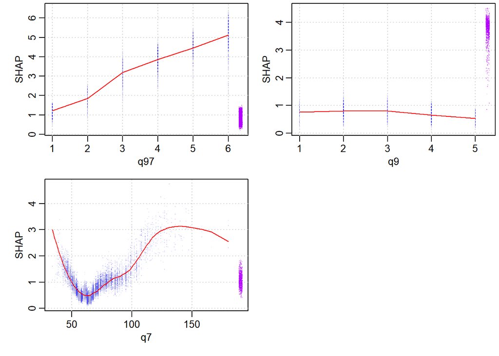

```r
xgb.plot.shap(model = xgb_l1, data=train_mat, top_n = 3, n_col = 2)
```

The top 3 important variables are: `q97`, `q9` and `q7`.

# Task 3

```r
# plot functions

r_total = sum(table(data$r))
rprop=array(1:8)
for (i in 1:8){
  rprop[i]=table(data$r)[i]/r_total
}

bar <- function(label,q){
  t = table(label, q, dnn = c("r","q"))
  for (i in 1:8){ t[i,]=t[i,]/rprop[i] }
  t = as.data.frame(t)
  return(ggplot(data=t,mapping=aes(x=factor(q),y=Freq,fill=r))+
    geom_bar(stat ="identity", position = "dodge") )
}
```

- q97

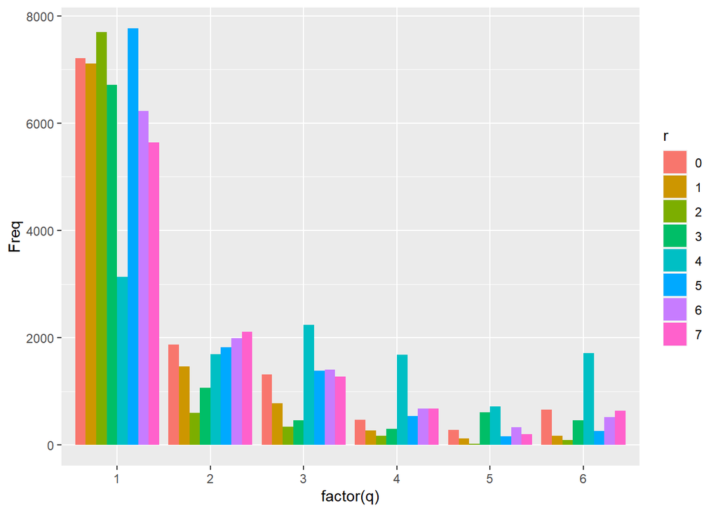

```r
bar(label = data$r, q = data$q97 )
```

- q9

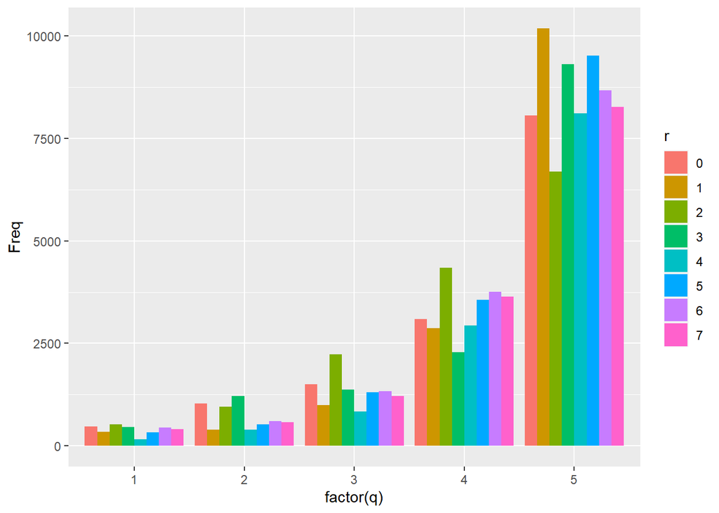

```r
bar(label = data$r, q = data$q9)
```

- q7

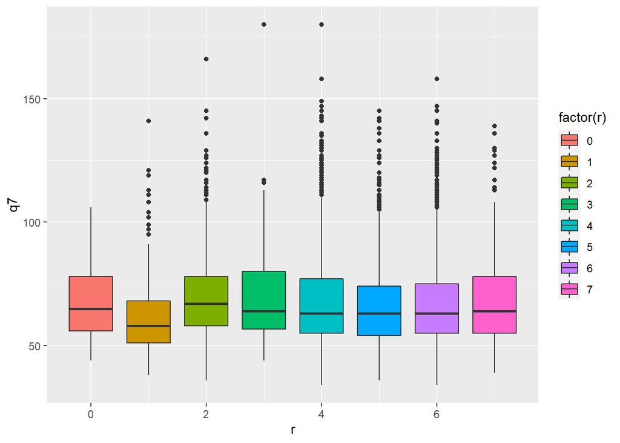

```r
tmp.df = train %>% filter(!is.na(q7))
qplot(r,q7,data = tmp.df ,geom= "boxplot", fill = factor(r))
```

No obvious factors.

Overall, feature q97 contributes most importance (gain 0.09) in discrimination.

# Task 4

Besides, this kind of data and prediciton will cause other problems such as ethnic stereotypes. Once the inaccurate predictions published, this will greatly decrease the authority of general surveys.